# Intro R Practice Problems - Week 1

Dr. Dani Kirsch & Dr. Jaina Agan

2026-08-10

To give you an opportunity to continue practicing your R skills between now and the next workshop session, we have provided a new dataset for you to use, along with some practice problems.

Feel free to refer back to the code you wrote during the first workshop session. It’s very common (and encouraged!) to recycle and modify code you and others have written.

## Dataset Description

`msleep` is a dataset that’s available in R as part of the `ggplot2` package, similar to the `complete_old` dataset we have been using from the `ratdat` package. The `msleep` dataset has information about different species of mammals and their sleep habits.

Write and execute the following code to read about where the dataset came from and what the variables are.

```r
?msleep
```

## Make a Scatter Plot

1. Create a scatter plot from the data that places `brainwt` (brain weight) on the x-axis and `sleep_total` on the y-axis.
2. Specify that the color of the points should vary based on the variable `vore`, which indicates the type of diet the animal has.
3. Change the transparency of the points to 0.8.
4. Transform the x-axis so it has a log10 scale using the `scale_x_log10` function.

**Reminders!**

- `geom_point` is the function used to tell ggplot2 to make a scatter plot
- `alpha =` is how we specify transparency

The scatter plot you create should look similar to the following graph:

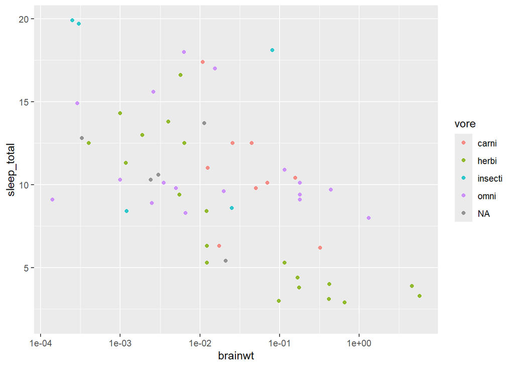

## Make a Boxplot

1. Create a boxplot from the data that uses `vore` (diet) as the x variable and `awake` (time awake in hours) as the y variable.
2. Specify that the boxes should be filled with color based on the variable `vore` (diet)
3. **Optional Bonus**: You can change the fill color of the boxes in a similar way to how we changed the color scale during the workshop. We used `scale_viridis_d` to change the **color** scale during the workshop. There is a similar function called `scale_fill_viridis_d` that works very similarly but operates on the **fill** variable instead.

**Reminder!**

- `fill =` is how we specify fill color

The boxplot you create should look similar to the following graph:

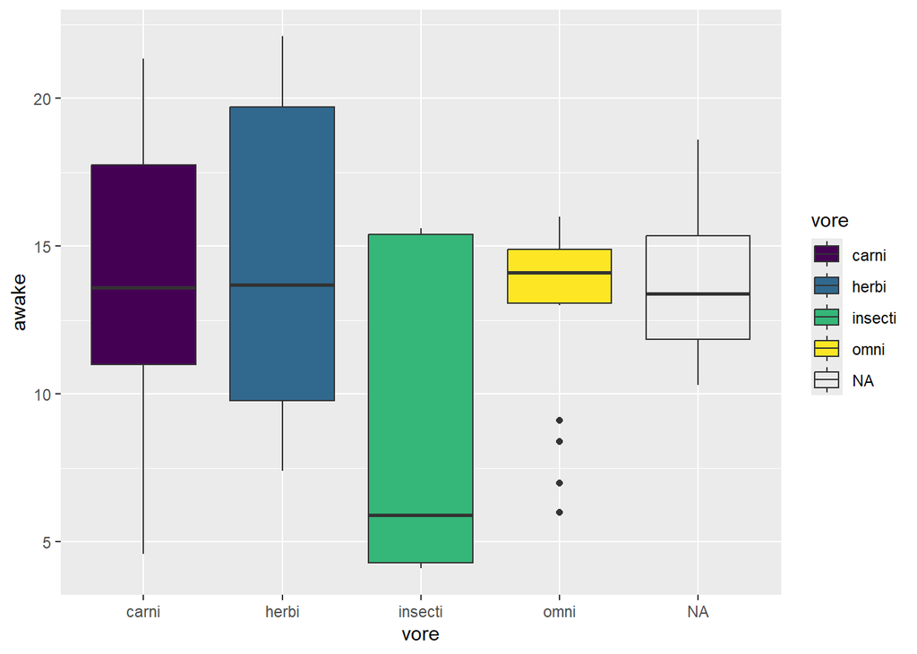

## Reflections

1. What was the most challenging aspect of this week’s workshop? Were you able to overcome it? If not, what assistance do you need to continue working through it?
2. What was the most rewarding aspect of this week’s workshop?

## Microcredential Submission

> Submit your Week 1 R script file and your reflections to Dr. Jaina Agan (jagan@uco.edu) or Dr. Dani Kirsch (danielle.kirsch@okstate.edu)